# Introduction to R Packages

Lee Richardson  
11/17/2015

### Outline

## Motivation

- Why take the time to write an R Package?

## General set-up

- Installing Devtools (How taking time to set-up holds people back. This package automates lots of the tedious steps for us and allows us to focus on the functionality of our code, rather than the hoops we need to make it work)
- Setting up the source directory
- Explain the components of an R Package, talk about the difference between binary and source, as well as installed and in memory.
- Writing our first function

## Documentation

- Introduce the roxygen package (story about how we used to write ad-hoc documentation atop of these functions. This actually automates this task for us)
- Document the first function
- Explain what is happening under the hood
- Show how to now view the documentation
  - Testing
- Reliability and trustworthy software (Chambers quote)
- Introducing the testthat package
- Writing a test of our function
- Running the test, verifying that things work
  - Syncing with Github
- Turning your source package into a git repository
- Syncing this package with your github account
- Uploading your package online to github
- Downloading other people packages FROM github (is this better or worse than CRAN? Why?)

### Why make an R Package?

- Share code/data/documentation with other R users
- Organization, standardized tools (testing, documentation, …)
- Fulfillment, building something

### A quote from the inventor

“… from user to programmer to contributor, in the gradual progress that R encourages. Specifically: using R; simple programming; **packages** and methods; inter-system interfaces”

John Chambers (Software for Data Analysis: Programming with R)

### What is an R Package?

- Collection of files, organized in a specific way which R users can attach to their session
- Packages are installed into libraries (see these using `.libPaths()`)
- Then they can be attached to the session using the `library()` function.

```r
  library(lattice)
  search()
```

### Devtools allows us to get our package up an running

“The goal of devtools is to make package development as painless as possible”

Hadley Wickham (R Packages)

```r
  install.packages("devtools")
  library("devtools")
```

- Provides a suite of functions which automate the low-level package details, which come with R itself

### Step 1: Initialize the repository

An R (*source*) package is just files in a directory, formatted in a specific way. To create the bare bones R package, just type:

```r
devtools::create("/home/lee/leeR")
```

This should give us:

1. Directory R/
2. NAMESPACE file
3. DESCRIPTION file
4. leeR.rproj file (if using R Studio)

### Here's what the directory should look like

[figure not shown]

### Description: The package meta-data

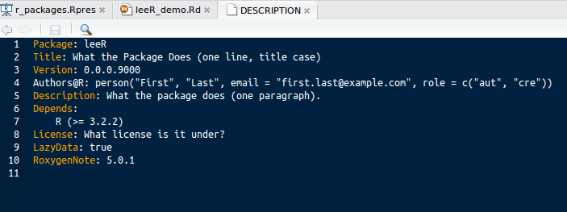

This is used to provide main documentation, describe the package

### Step 2: Write a function!

Now, create a file in the `R/` directory for our first function. For example, we can create the file `R/examples.R` and add the function:

```r
leeR_demo <- function() {
  print("Hello World!")
}
```

Now, we can load the package into memory:

```r
devtools::load_all()
```

### What just happened?

`devtools::load_all()` takes your source package and load's it into R's memory, skipping the installation process

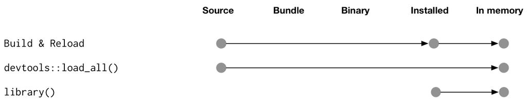

R Packages, Chapter 1

Note that we commonly do this with `library()` and installed functions

### Step 3: Documentation our functions

R provides a way to document functions in packages, storing `.Rd` files in the `man/` directory

At its core, R takes `.Rd` files location in a `man/` directory and renders them into either html, pdf, or whichever format is needed. But as you might guess…

### Roxygen2 function automates the documentation process

The easiest way to document your R functions is through the `roxygen2` package, which allows you to combine the code and documentation into a single file.

```r
install.packages("roxygen2")
library(roxygen2)
```

### We can write the documentation right above our functions

```r
#' Print Hello World!
#'
#' @return A string saying "Hello World"
#' @examples
#' leeR_demo()
leeR_demo <- function() {
  print("Hello World!")
}
```

### Devtools provides a wrapper for roxygen2

As a standard workflow, we can use:

```r
devtools::document()
```

Now, this will create a `man/` folder, and insert the corresponding `man/leeR_demo.Rd` file that R uses to generate documentation. Let's see what this looks like:

```r
% Generated by roxygen2: do not edit by hand
% Please edit documentation in R/examples.R
\name{leeR_demo}
\alias{leeR_demo}
\title{Print Hello World!}
\usage{
leeR_demo()
}
\value{
A string saying "Hello World"
}
\description{
Print Hello World!
}
\examples{
leeR_demo()
}
```

### We can now view our documentation in the standard R format

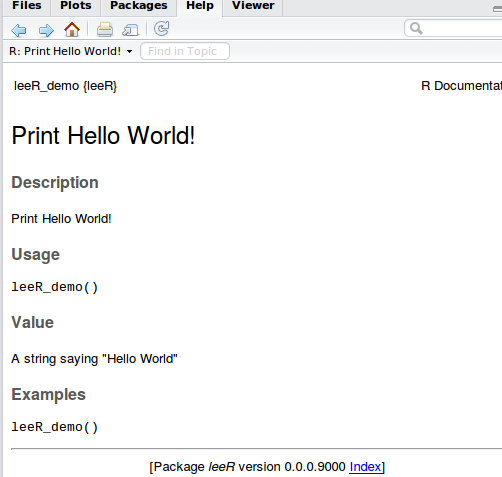

`?leeR_demo`

### Step 4: Testing

Testing packages is critical to making sure your packages are trustworthy.

Devtools integrates with the `testthat` package to help automatic testing of your functions

```r
install.packages("testthat")
devtools::use_testthat()
```

This will set up the `tests/testthat` directory where we can store tests

### Testing our function

Next, let's create a file `tests/testthat/test-example.R`

```r
context("Test our example")

test_that("our function works", {
  expect_equal(leeR_demo(), "Hello World!")
})
```

Now run:

```r
devtools::test()
```

To make sure things are working

### Step 5: Syncronizing with Github

This allows users to install your package without being hosted on CRAN. For example, you could install the R package I just made using:

```r
devtools::install_github(username = "leerichardson", repo = "leeR")
library(leeR)
?leeR_demo
leeR_demo()
```

Amazingly, we've been able to write a pack for others to download within 30 minutes!

### Instructions for syncronizing with Github

1. Create a Github repository with the same name as your package
2. Use the following commands from the command line:

```r
# echo "# packagename" >> README.md
# git init
# git add --all
# git commit -m "First Commit!"
# git remote add origin https://github.com/username/packagename.git
# git push -u origin master
```

Now check out the Github page, all of the code is there!

### Congratulations! You now have your own personal R Package

There are many more great features of to look into, including:

- Including data (git/github)
- Vignettes (long form documentation, knitr)
- Compiled code (C, C++, Fortran…)

Many more details in the “R Packages” book by Hadley Wickham

Thanks!

Questions?